# RLunchandLearn2

DeMel Mojica  
Wednesday 07-20-16

### ggplot2: The Grammar of Graphics

### Starting Point: Data Frames

We set the restriction that all our data exists in a matrix called a **data frame**, which we say has the “tidy” property:

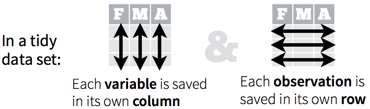

### What is a statistical graphic?

[Wilkinson (2005)](http://link.springer.com/book/10.1007/0-387-28695-0/page/1) boils it down:

In brief, the grammar tells us that a statistical graphic is a mapping from **data** to **aesthetic** attributes (color, shape, size) of **geometric** objects (points, lines, bars).

### Example: Napolean's March on Moscow

Famous graphical illustration by Minard of Napolean's march to and retreat from Moscow in 1812

[figure not shown]

### The Grammar

| Data (Variable) | Aesthetic | Geometric Object |
| --- | --- | --- |
| longitude |  | points |
| latitude |  | points |
| army size | size = width | bars |
| army direction | color = brown or black | bars |
| date |  | text |
| temperature |  | lines |

### The Grammar

The plot may also contain **statistical transformations** of the data. Ex: histograms transform numbers into counts that fall into bins

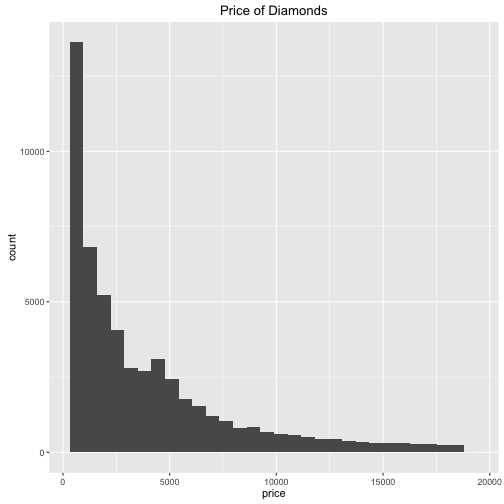

### Basic Components

- **`aes`** mappings of data to *aesthetics* we can perceive on a graphic: x/y position, color, size, and shape. Each aesthetic can be mapped to a variable in our data set. If not assigned, they are set to defaults.
- **`geom`** geometric objects: type of plot: points, lines, bars, etc.
- **`stat`** statistical transformations to summarise data: smoothing, binning values into a histogram, or just itself “identity”

### More Components

- **`facet`** how to break up data into subsets and display broken down plots
- **`scales`** both
  - convert **data units** to **physical units** the computer can display
  - draw a legend and/or axes, which provide an inverse mapping to make it possible to read the original data values from the graph.
- **`coord`** coordinate system for x/y values: typically cartesian.
- **`position`** adjustments
- **Extras** titles, axes labels, themes

### Follow Up Examples (on your own)

Open `ggplot.R` in RStudio and do examples.

### Further Reading Ressources

- Help files. Ex `?geom_line()`
- Online help files: http://docs.ggplot2.org/current/
- [Ultimate Tech Support](http://xkcd.com/627/)
- ggplot2 book is on Slack To learn more, I suggest reading
  - Chapter 1,
  - Chapter 3, but it will be hard to grasp the first time
  - Chapter 4
  - Revisit Chapter 3. Chapters 5-10 go into specific details.
- The code for all examples in the book: http://ggplot2.org/book/

### Review of So far: Basic Components

- **`aes`** mappings of data variables to aesthetics we can perceive on a graphic
- **`geom`** geometric objects
- **`stat`** statistical transformations to summarise data
- **`facet`** how to break up plots into subsets
- **`coord`** coordinate system for x/y values: typically cartesian (can be polar)
- **`scale`** both convert **data units** to **physical units** the computer can display AND draw a legend/axes.
- **Extras** titles, axes labels, themes

### Further Reading Ressources

- Help files. Ex `?geom_line()`
- Online help files: http://docs.ggplot2.org/current/
- [Ultimate Tech Support](http://xkcd.com/627/)
- ggplot2 book is on Moodle. To learn more, I suggest reading
  - Chapter 1,
  - Chapter 3, but it will be hard to grasp the first time
  - Chapter 4
  - Revisit Chapter 3. Chapters 5-10 go into specific details.
- The code for all examples in the book: http://ggplot2.org/book/

### ggplot2: More Components/Concepts

- **layers**: mechanism by which additional data elements are added to a plot
- **`position`** adjustments: minor tweeks to the position of elements
- **groups**: splitting data into groups within the same plot (not via facets)

### Building a Graphic Layer-by-Layer

We build plots by adding **layers**. Each layer consists of:

1. data and aesthetic mappings (the base)
2. geometric object
3. statistical transformation (with default values)
4. position adjustment (with default values)

### Building a Graphic Layer-by-Layer

Notes:

- Make the base as general as possible
- Every `geom` has a default `stat` & `position` value if they aren't specified
- Layer settings override plot defaults
- You can save plots as variables and add to variables, to reduce duplication

### Examples for Today

In `ggplot_2.R` we have examples of

- setting groups: `Examples of groups`.
- many different types of geoms: `Examples of geoms`.
- `geom_histogram()` and **position adjustments**: [Titanic Survival Data](https://www.youtube.com/watch?v=zisjRgcuL9k)

### Today's Question: UC Berkeley Admissions

In 1973, the UC Berkeley was sued for bias against women who had applied for admission to graduate schools. n=4526 applicants:

```
Source: local data frame [4 x 3]
Groups: Admit [?]

     Admit Gender  Freq
    <fctr> <fctr> <dbl>
1 Admitted   Male  1198
2 Admitted Female   557
3 Rejected   Male  1493
4 Rejected Female  1278
```

### Today's Question: UC Berkeley Admissions

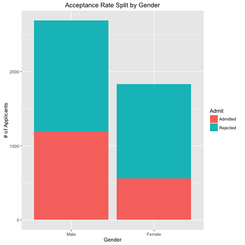

### Today's Question: UC Berkeley Admissions

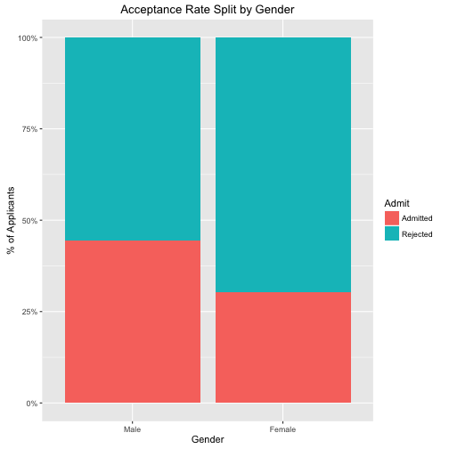

### Today's Question: UC Berkeley Admissions

However, there was another variable researchers could consider: department applied to.

```
# A tibble: 24 x 4
      Admit Gender   Dept  Freq
     <fctr> <fctr> <fctr> <dbl>
1  Admitted   Male      A   512
2  Rejected   Male      A   313
3  Admitted Female      A    89
4  Rejected Female      A    19
5  Admitted   Male      B   353
6  Rejected   Male      B   207
7  Admitted Female      B    17
8  Rejected Female      B     8
9  Admitted   Male      C   120
10 Rejected   Male      C   205
# ... with 14 more rows
```

### Today's Question: UC Berkeley Admissions

Investigate:

1. Construct a statistical graphic showing how male vs female acceptance varied by department. Bonus: Using google, make one of the axes reflect percentage of applicants.
2. Construct a statistical graphic showing the “competitiveness” of the department as measured by acceptance rate.